# Stemming, lematyzacja

Bogna Zacny

zima 2019/2020

## Przygotowanie środowiska

Przydatne pakiety

```
install.packages(c("tm", "stringr", "SnowballC")

library("stringr")
library("tm")
library(""SnowballC"")
```

Przestrzeń robocza

```
setwd("C:/Users/UE/Documents/R")
```

## Stemming

Dla przypomnienia, najpopularniejsze wyrazy z tweetów o kawie, gdy w procesie przygotowania tekstu **nie** wykorzystuje się stemmingu (ekstrakcji rdzenia wyrazu).

```r
kawa <- read.csv2("coffee_tweets.csv")
kawa_zrodlo <- VectorSource(kawa$text)
kawa_korp <- VCorpus(kawa_zrodlo)

czysc_korpus <- function(corpus, slowa = ""){
  corpus <- tm_map(corpus, stripWhitespace)
  corpus <- tm_map(corpus, removePunctuation)
  corpus <- tm_map(corpus, content_transformer(tolower))
  corpus <- tm_map(corpus, removeNumbers)
  corpus <- tm_map(corpus, removeWords, c(stopwords("en"), slowa))
  return(corpus)
}

kawa_czysty <- czysc_korpus(kawa_korp, "coffee")

kawa_tdm <- TermDocumentMatrix(kawa_czysty)
kawa_m <- as.matrix(kawa_tdm)

kawa_term <- rowSums(kawa_m)
kawa_term <- sort(kawa_term, decreasing = TRUE)
```

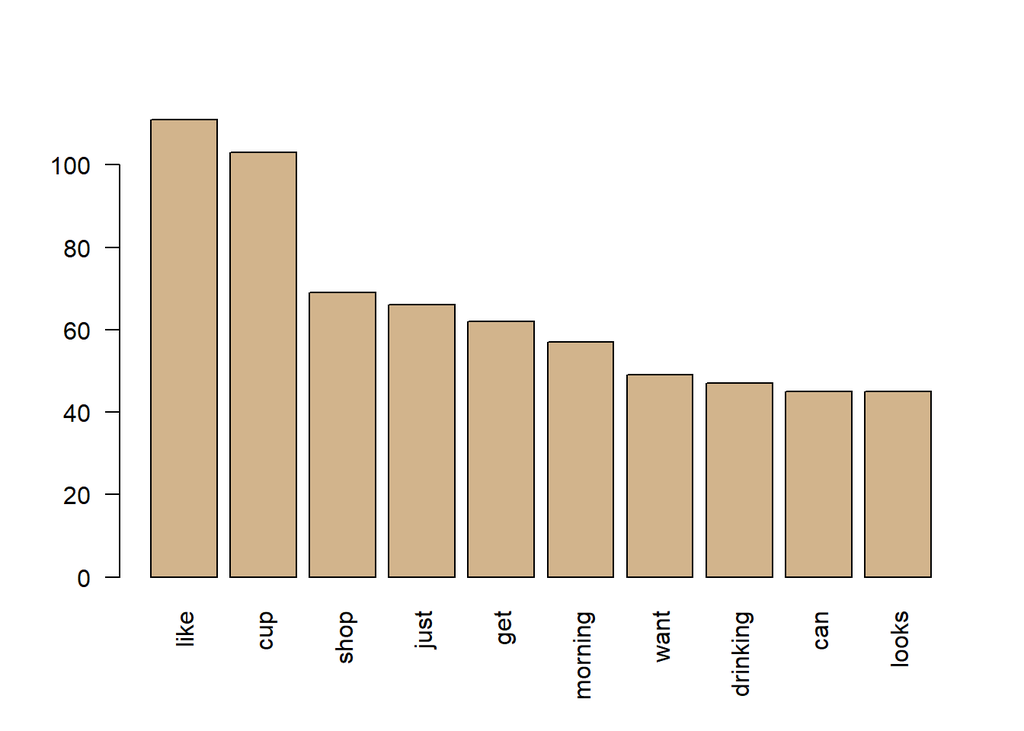

```r
# Wizualizacja 10 najczęstszych termów
barplot(kawa_term[1:10], col = "tan", las = 2)
```

#### Stemming dla wektora wyrazów

Funkcja **`stemDocument{tm}`** pozwala na zastosowanie algorytmu Portera do wyodrębnienia rdzenia z wyrazów. Dla przykładu wektor wyrazów **`"argue", "argued", "argues", "arguing"`**.

```r
slowa<-c( "argue", "argued", "argues", "arguing")

rdzen <- stemDocument(slowa)
rdzen
```

```
## [1] "argu" "argu" "argu" "argu"
```

Utworzenie z rdzeni zrozumiałych wyrazów.

```r
# słownik uzupełnień
slownik <- c("argue")

kompletne_slowa <- stemCompletion(rdzen, slownik)
kompletne_slowa
```

```
##    argu    argu    argu    argu
## "argue" "argue" "argue" "argue"
```

#### Stemming dla zdania

Zastosowanie algorytmu Portera do wyodrębnienia rdzenia z wyrazów w zdaniu **`"John is argumentative. He argues about everything, yesterday was arguing for one penny"`**.

```r
stemDocument("John is argumentative. He argues about everything, yesterday was arguing for one penny")
```

```
## [1] "John is argumentative. He argu about everything, yesterday was argu for one penni"
```

Przed wywołaniem funkcji `stemDocument()`, należy przygotować tekst, w przypadku powyższego zdania wystarczy usunąć jedynie zbędne znaki przestankowe i wyodrębnić tokeny rozdzielone jednym znakiem spacji (wyrazy).

```r
tekst <- "John is argumentative. He argues about everything, yesterday was arguing for one penny"

# przygotowanie tekstu
tekst_punc <- removePunctuation(tekst)

# tokenizacja
slowa <- str_split(tekst_punc, ' ')

# wyszukanie rdzenia
rdzenie <- stemDocument(slowa[[1]])

# lub
rdzenie <- stemDocument(unlist(slowa))

rdzenie
```

```
##  [1] "John"      "is"        "argument"  "He"        "argu"
##  [6] "about"     "everyth"   "yesterday" "was"       "argu"
## [11] "for"       "one"       "penni"
```

Utworzenie z rdzeni zrozumiałych wyrazów za pomocą funkcji **`stemCompletion{tm}`**.

1. Z wykorzystaniem słownika uzupełnień:

```r
# słownik uzupełnień
slownik <- c("argue", "everything", "penny")

kompletne_slowa <- stemCompletion(rdzen, slownik)
```

2. Z wykorzystaniem oryginalnego tekstu. Rozwiązanie stosowane gdy nie można utworzyć słownika uzupełnień - przy dużych korpusach gdy liczba tokenów sięga tysięcy niemożliwe jest utworzenie sensownego słownika. Funkcja `stemCompletion()` pozwala na określenie metody wyboru wyrazów “kompletnych” z tekstu oryginalnego `?stemCompletion`.

```r
kompletne_slowa <- stemCompletion(rdzen, unlist(slowa), type = "prevalent")
```

#### Zadanie

Żadne z powyższych rozwiązań nie zwróciło oczekiwanego wyniku, zaproponuj rozwiązanie, które pozwoli na stworzenie kompletnego (bez pustych elementów) wektora wyrazów kompletnych, przy jednoczesnym wykorzystaniu wyników stemmingu.

#### Stemming dla korpusu

```r
kawa_stem <- tm_map(kawa_czysty, stemDocument)

kawa_stem_tdm <- TermDocumentMatrix(kawa_stem)
kawa_stem_m <- as.matrix(kawa_stem_tdm)

kawa_stem_term <- rowSums(kawa_stem_m)
kawa_stem_term <- sort(kawa_stem_term, decreasing = TRUE)
```

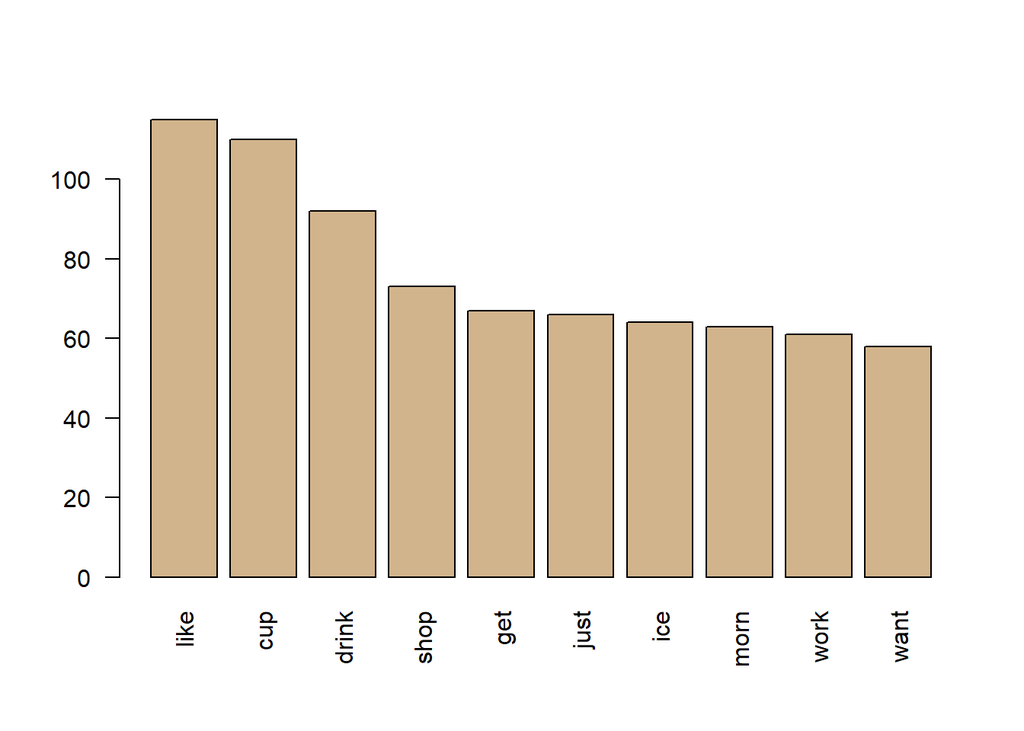

```r
# Wizualizacja 10 najczęstszych termów po stemmingu
barplot(kawa_stem_term[1:10], col = "tan", las = 2)
```

```r
cat("Liczba wyodrębnionych termów z korpusu tweetów o kawie, po dokonaniu stremmingu spadła o", dim(kawa_m)[1]-dim(kawa_stem_m)[1], "termy" )
```

```
## Liczba wyodrębnionych termów z korpusu tweetów o kawie, po dokonaniu stremmingu spadła o 292 termy
```

## Lematyzacja

#### Przygotowanie zbioru dokumentów

W przykładzie korpus składa się z “dokumentów”, będących zdaniami - przysłowiami polskimi.

```r
przyslowia <- scan("przyslowia.txt", encoding = "UTF-8", what="character", sep=",")

przyslowia_czyste <- removePunctuation(przyslowia)
przyslowia_czyste <- str_replace(przyslowia_czyste, "–", "")

przyslowia_czyste <- tolower(przyslowia_czyste)

stopWords <- c("czego", "czy", "i", "tego", "w", "z")
przyslowia_czyste <- removeWords(przyslowia_czyste, stopWords)

przyslowia_czyste <- stripWhitespace(przyslowia_czyste)
przyslowia_czyste <- str_trim(przyslowia_czyste)
```

#### Przygotowanie słownika

Słownik (dla języka polskiego) zawierający zbiór form podstawowych (lemm) i form wyrazowych (wyrazów odmienionych) można pobrać z [repozytorium](https://github.com/morfologik/polimorfologik/releases/tag/2.1).

Wczytanie słownika

```r
slownik <- read.csv2("polimorfologik-2.1.txt", encoding = "UTF-8", header=F, stringsAsFactors=FALSE)
```

Warto sprawdzić czy proces wczytania pliku przebiegł poprawnie:

```r
dim(slownik) # 3 kolumny i brdzo dużo wierszy: 4 811 854

slownik[3604764,]
slownik[1007902,]
slownik[2581393,]
slownik[700:710,]
```

Niektóre wyrazy odmienione mają kilka form podstawowych np: `"kotki" -> "kotek", "kotka"`, w niektórych zastosowaniach NLP można usunąć zdublowane formy odmienione aby przyspieszyć proces lematyzacji.

```r
slownik <- slownik[!duplicated(slownik[,2]),1:2]
```

Powyższy kod odnajdzie w `slownik`u wszystkie zdublowane wiersze ze względu na zawartość kolumny 2 i zwróci wiersze **nie** zawierające dubli, ponadto usunięta zostanie kolumna 3 zawierająca znaczniki gramatyczne. Dla zrozumienia działania kodu warto przeanalizować trywialny przykład

```r
slownikTest<-data.frame(podstawa=c("być", "być","być"), odmiana = c("jest", "jestem", "jest"), stringsAsFactors = FALSE)

slownikTest[!duplicated(slownikTest[,2]),]
```

```
##   podstawa odmiana
## 1      być    jest
## 2      być  jestem
```

Do zamiany wyrazów odmienionych na formę podstawową wykorzystać można funkcję **`str_replace_all{stringr}`**. Funkcja ta przyjmuje trzy argumenty `(string, pattern, replacement)` co w procesie lematyzacji można zapisać jako: `(token, forma_odmieniona, forma_podstawowa)`.

Przykład trywialny:

```r
# Zamiana dla jednego wzorca formy odmienionej i formy podstawowej
str_replace_all(c("Dzisiaj, Bartłomieja nie będzie", "Bartek, dzisiaj się nie pojawił"),
                "Bartek",
                "Bartłomiej")
```

```
## [1] "Dzisiaj, Bartłomieja nie będzie"
## [2] "Bartłomiej, dzisiaj się nie pojawił"
```

```r
# Gdy wzorce znajdują się w tabeli
slownikBart<-data.frame(podst=c("Bartłomiej", "Bartłomiej"), odmiana=c("Bartłomieja", "Bartek"), stringsAsFactors = FALSE)

str_replace_all(c("Dzisiaj, Bartłomieja nie będzie", "Bartek, dzisiaj się nie pojawił"),
                slownikBart[2,2],
                slownikBart[2,1])
```

```
## [1] "Dzisiaj, Bartłomieja nie będzie"
## [2] "Bartłomiej, dzisiaj się nie pojawił"
```

```r
# Zamiana dla kilku wzorców formy odmienionej i formy podstawowej
str_replace_all(c("Dzisiaj, Bartłomieja nie będzie", "Bartek, dzisiaj się nie pojawił"),
                c("Bartek", "Bartłomieja", "będzie"),
                c("Bartłomiej", "Bartłomiej", "być"))
```

```
## [1] "Dzisiaj, Bartłomieja nie będzie" "Bartek, dzisiaj się nie pojawił"
## [3] "Dzisiaj, Bartłomieja nie być"
```

Niestety funkcja nie zwraca poprawnego wyniku bowiem, funkcja “nie wie” który wzorzec na który wzorzec podmienić.

```r
# Gdy wzorce znajdują się w tabeli
slownikBart<-data.frame(podst=c("Bartłomiej", "Bartłomiej", "być"), odmiana=c("Bartłomieja", "Bartek", "będzie"), stringsAsFactors = FALSE)

str_replace_all(c("Dzisiaj, Bartłomieja nie będzie", "Bartek, dzisiaj się nie pojawił"),
                slownikBart[,2],
                slownikBart[,1])
```

```
## [1] "Dzisiaj, Bartłomiej nie będzie"
## [2] "Bartłomiej, dzisiaj się nie pojawił"
## [3] "Dzisiaj, Bartłomieja nie być"
```

Także i w tym wypadku wynik odbiega od oczekiwanego, bowiem każdy ze stringów został poddany przekształceniu aż trzy razy (tyle ile jest wierszy w tabeli z parami wzorców) a co najgorsze każde z trzech przekształceń jest niezależne, więc string `"Dzisiaj, Bartłomieja nie będzie"` raz przekształcony został do postaci `"Dzisiaj, Bartłomiej nie będzie"` a za kolejnym - `"Dzisiaj, Bartłomieja nie być"`.

Funkcja `str_replace_all()` pozwala na wprowadzenie wielu par wzorców forma_odmieniona/forma_podstawowa, w postaci wektora stringów, gdzie każdy element wektora to forma podstawowa a nazwa tego elementu to forma odmieniona.

```r
# Stworzenie wektora z wyrazów w formie podstawowej (1. kolumna słownika)
podstawaBart<-slownikBart[,1]

# Nadanie nazw elementom wektora w postaci wyrazów w formie odmienionej (2. kolumna słownika)
names(podstawaBart)<-slownikBart[,2]
podstawaBart
```

```
##  Bartłomieja       Bartek       będzie
## "Bartłomiej" "Bartłomiej"        "być"
```

```r
# Zamiana wyrazów z formy odmienionej na formę podstawową
str_replace_all(c("Dzisiaj, Bartłomieja nie będzie", "Bartek, dzisiaj się nie pojawił"),
                podstawaBart)
```

```
## [1] "Dzisiaj, Bartłomiej nie być"
## [2] "Bartłomiej, dzisiaj się nie pojawił"
```

Lematyzacji wszystkich przysłów, można dokonać z wykorzystaniem słownika polimorfigik:

```r
podstawa<-slownik[,1]
names(podstawa)<-slownik[,2]
przyslowia_lemmy <- str_replace_all(przyslowia_czyste, podstawa)
```

lub uproszczonej wersji:

```r
slownikMaly <- read.csv2("slownik.txt", header=F, stringsAsFactors=FALSE)
podstawaMaly<-slownikMaly[,1]
names(podstawaMaly)<-slownikMaly[,2]
przyslowia_lemmy <- str_replace_all(przyslowia_czyste, podstawaMaly)
przyslowia_lemmy
```

```
##  [1] "jesień nie zrodzić wiosna nie zasiać"
##  [2] "wiosna nie zasiać jesień nie urodzić"
##  [3] "święty bartłomiej pogodny jesień pogodny"
##  [4] "bartłomiej zwiastować jaki jesień następować przyszły lat dożyć dostatek"
##  [5] "bartłomiej zwiastować jaki jesień następować"
##  [6] "bartłomiej cały wrzesień naśladować nim jesień"
##  [7] "bartłomiej świętyięty dzień jaki zostać pora taki jesień bez ochyby dać"
##  [8] "jaki bartłomiej nieść dzień taki być jesień"
##  [9] "jaki bartłomiej nieść dzień taki być jesień"
## [10] "jaki bartłomiej taki wrzesień jaki marcin taki zima"
```

Po lematyzacji można stworzyć macierz term-dokument i przystąpić do jej analizy:

```r
przyslowia_zrodlo <- VectorSource(przyslowia_lemmy)
przyslowia_korp <- VCorpus(przyslowia_zrodlo)

przyslowia_tdm <- TermDocumentMatrix(przyslowia_korp)
inspect(przyslowia_tdm)
```

```
## <<TermDocumentMatrix (terms: 32, documents: 10)>>
## Non-/sparse entries: 65/255
## Sparsity           : 80%
## Maximal term length: 10
## Weighting          : term frequency (tf)
## Sample             :
##             Docs
## Terms        1 10 2 3 4 5 6 7 8 9
##   bartłomiej 0  1 0 1 1 1 1 1 1 1
##   być        0  0 0 0 0 0 0 0 1 1
##   dzień      0  0 0 0 0 0 0 1 1 1
##   jaki       0  2 0 0 1 1 0 1 1 1
##   jesień     1  0 1 1 1 1 1 1 1 1
##   następować 0  0 0 0 1 1 0 0 0 0
##   nie        2  0 2 0 0 0 0 0 0 0
##   nieść      0  0 0 0 0 0 0 0 1 1
##   pogodny    0  0 0 2 0 0 0 0 0 0
##   taki       0  2 0 0 0 0 0 1 1 1
```

```r
nTerms(przyslowia_tdm)
```

```
## [1] 32
```

```r
Terms(przyslowia_tdm)
```

```
##  [1] "bartłomiej" "bez"        "być"        "cały"       "dać"
##  [6] "dostatek"   "dożyć"      "dzień"      "jaki"       "jesień"
## [11] "lat"        "marcin"     "następować" "naśladować" "nie"
## [16] "nieść"      "nim"        "ochyby"     "pogodny"    "pora"
## [21] "przyszły"   "święty"     "świętyięty" "taki"       "urodzić"
## [26] "wiosna"     "wrzesień"   "zasiać"     "zima"       "zostać"
## [31] "zrodzić"    "zwiastować"
```

```r
findFreqTerms(przyslowia_tdm, 4)
```

```
## [1] "bartłomiej" "jaki"       "jesień"     "nie"        "taki"
```

Konwersja macierzy term-dokument do tradycyjnej macierzy

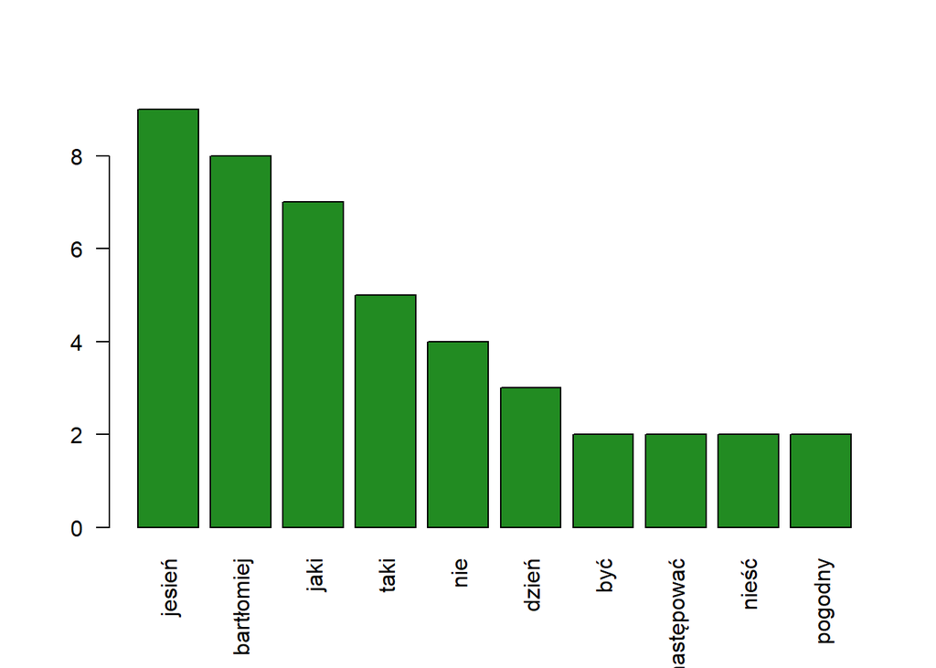

```r
przyslowia_m <- as.matrix(przyslowia_tdm)
przyslowia_term <- rowSums(przyslowia_m)
przyslowia_term <- sort(przyslowia_term, decreasing = TRUE)

# Wizualizacja 10 najczęstszych termów
barplot(przyslowia_term[1:10], col = "forestgreen", las = 2)
```